# INFO-4604/5604 HW2: Linear Classification

### Solution by: *Johnny Sreenan*

## Assignment overview

News agencies, governments and corporations sometimes track social media during natural disasters to try to monitor unfolding events. But because no single person or group of people can read all available Twitter data, organizations may turn to natural language processing methods to try and understand what is happening as disasters unfold.

While this approach is powerful, inferring events from NLP can be tricky. For instance, say a person [tweets](https://twitter.com/AnyOtherAnnaK/status/629195955506708480) that "LOOK AT THE SKY LAST NIGHT IT WAS ABLAZE." This tweet includes the word "ablaze", which may signal to a computer that there is an unfolding disaster. However, in this particular case, the person is speaking metaphorically. A simple computer system using keywords (e.g. ablaze) might be fooled into thinking the tweet is reporting an actual fire.

In this assignment, you will predict if a given tweet actually refers to a natural disaster. This exercise is motivated by real-world disaster monitoring systems, and can help you to gain practice with supervised binary classification and natural language processing.

**Note**: This dataset originally comes from [Kaggle](https://www.kaggle.com/c/nlp-getting-started/overview). But it has been modified for this problem set. Information about the data from this problem set that you find on Kaggle will almost certainly be wrong.

### What to hand in

You will submit the assignment on Canvas. Submit a single Jupyter notebook named `hw2lastname.ipynb`, where lastname is replaced with your last name. **Please also submit a PDF or HTML version of your notebook to Canvas**.

Please clearly mark all deliverables. You are encouraged to create additional cells in whatever way makes the presentation more organized and easy to follow. You are allowed to import additional Python libraries.

### Submission policies

- **Collaboration:** You are allowed to work with one partner. You are still expected to write up your own solution. Each individual must turn in their own submission, and list your collaborators after your name.
- **Late submissions:** Each student may use up to 5 late days over the semester. You have late days, not late hours. This means that if your submission is late by any amount of time past the deadline, then this will use up a late day. If it is late by any amount beyond 24 hours past the deadline, then this will use a second late, and so on. Once you have used up all late days, late assignments will be given at most 80% credit after one day and 60% credit after two days.

## Getting started

In this assignment, you will experiment with perceptron and logistic regression in `sklearn`. Much of the code has already been written for you. We will use a class called `SGDClassifier` (which you should read about in the [sklearn documentation](http://scikit-learn.org/stable/modules/generated/sklearn.linear_model.SGDClassifier.html)), which implements stochastic gradient descent (SGD) for a variety of loss functions, including both perceptron and logistic regression, so this will be a way to easily move between the two classifiers.

The code below will load the datasets. There are two data collections: the "training" data, which contains the tweets that you will use for training the classifiers, and the "testing" data, which are tweets that you will use to measure the classifier accuracy. The test tweets are instances the classifier has never seen before, so they are a good way to see how the classifier will behave on data it hasn't seen before. However, we still know the labels of the test tweets, so we can measure the accuracy.

For this problem, we will use what are called "bag of words" features, which are commonly used when doing classification with text. Each feature is a word, and the value of a feature for a particular tweet is number of times the word appears in the tweet (with value $0$ if the word does not appear in the tweet).

A note on labels: **If `Y_train` or `Y_test` are 1 this means the tweet refers to a real disaster; if the values are 0, it means the tweet does not refer to a real disaster**

Run the block of code below to load the data. You don't need to do anything yet. Move on to "Problem 1" next.

```python
import pandas as pd
import numpy as np
from sklearn.feature_extraction.text import CountVectorizer

df_train = pd.read_csv('train.csv')

Y_train = df_train["target"]
text_train = df_train["text"]

vec = CountVectorizer()
X_train = vec.fit_transform(text_train)
feature_names = np.asarray(vec.get_feature_names())

df_test = pd.read_csv('test.csv')
Y_test = df_test["target"]
text_test = df_test["text"]

X_test = vec.transform(text_test)

print(df_train)
```

```
      Unnamed: 0     id keyword location  \
0              0      1     NaN      NaN
1              2      5     NaN      NaN
2              3      6     NaN      NaN
3              4      7     NaN      NaN
4              5      8     NaN      NaN
...          ...    ...     ...      ...
6115        7607  10867     NaN      NaN
6116        7608  10869     NaN      NaN
6117        7609  10870     NaN      NaN
6118        7611  10872     NaN      NaN
6119        7612  10873     NaN      NaN

                                                   text  target
0     Our Deeds are the Reason of this #earthquake M...       1
1     All residents asked to 'shelter in place' are ...       1
2     13,000 people receive #wildfires evacuation or...       1
3     Just got sent this photo from Ruby #Alaska as ...       1
4     #RockyFire Update => California Hwy. 20 closed...       1
...                                                 ...     ...
6115  #stormchase Violent Record Breaking EF-5 El Re...       1
6116  Two giant cranes holding a bridge collapse int...       1
6117  @aria_ahrary @TheTawniest The out of control w...       1
6118  Police investigating after an e-bike collided ...       1
6119  The Latest: More Homes Razed by Northern Calif...       1

[6120 rows x 6 columns]
```

## Problem 1: Understand the data [3 points]

Before doing anything else, take time to understand the code above.

The variables `df_train` and `df_test` are dataframes that store the training (and testing) datasets, which are contained in comma-separated files where the first column is the label and the second column is the text of the tweet.

The [`CountVectorizer`](http://scikit-learn.org/stable/modules/generated/sklearn.feature_extraction.text.CountVectorizer.html) class converts the raw text into a bag-of-words into a feature vector representation that `sklearn` can use.

You should print out the values of the variables and write any other code needed to answer the following questions.

#### Deliverable 1.1

How many training instances are in the dataset? How many test instances?

**(6120, 1493)**

#### Deliverable 1.2

How many features are in the training data?

#### Deliverable 1.3

What is the distribution of labels in the training data? That is, what percentage of instances are about actual disasters?

**43.2%**

# Deliverable 1.1

```python
print("There are",len(df_train),"training instances and",len(df_test),"testing instances in the dataset.")
```

```
There are 6120 training instances and 1493 testing instances in the dataset.
```

# Deliverable 1.2

```python
Features = len(df_train.columns) - 1
print("There are",Features,"features in the training data.")
```

```
There are 5 features in the training data.
```

# Deliverable 1.3

```python
target_inst = df_train["target"]
actual = 0
unrelated = 0
for i in range(len(target_inst)):
    if target_inst[i] == 1:
        actual +=1
    else:
        unrelated+=1

perc_inst= round(actual/(actual+unrelated)*100,2)
print("the percentage of instances that are about actual disasters is",str(perc_inst) + '%.')
# could use np.mean()
```

```
the percentage of instances that are about actual disasters is 43.2%.
```

## Problem 2: Perceptron [3 points]

The code below trains an [`SGDClassifier`](http://scikit-learn.org/stable/modules/generated/sklearn.linear_model.SGDClassifier.html) using the perceptron loss, then it measures the accuracy of the classifier on the test data, using `sklearn`'s [`accuracy_score`](http://scikit-learn.org/stable/modules/generated/sklearn.metrics.accuracy_score.html) function.

The `fit` function trains the classifier. The feature weights are stored in the `coef_` variable after training. The `predict` function of the trained `SGDClassifier` outputs the predicted label for a given instance or list of instances.

Additionally, this code displays the features and their weights in sorted order, which you may want to examine to understand what the classifier is learning. In general, in binary classification, the 0 class is considered the "negative" class.

There are 3 keyword arguments that have been added to the code below. It is important you keep the same values of these arguments whenever you create an `SGDClassifier` instance in this assignment so that you get consistent results. They are:

- `max_iter` is one of the stopping criteria, which is the maximum number of iterations/epochs the algorithm will run for.
- `tol` is the other stopping criterion, which is how small the difference between the current loss and previous loss should be before stopping.
- `random_state` is a seed for pseudorandom number generation. The algorithm uses randomness in the way the training data are sorted, which will affect the solution that is learned, and even the accuracy of that solution.

Note: *Wait a minute $-$ in class we learned that the loss function is convex, so the algorithm will find the same minimum regardless of how it is trained. Why is there random variation in the output? The reason is that even though there is only one minimum value of the loss, there may be different weights that result in the same loss, so randomness is a matter of tie-breaking. What's more, while different weights may have the same loss, they could lead to different classification accuracies, because the loss function is not the same as accuracy. (Unless accuracy was your loss function... which is possible, but uncommon because it turns out to be a difficult function to optimize.) Note that different computers may still give different answers, despite keeping these settings the same, because of how pseudorandom numbers are generated with different operating systems and Python environments.*

To begin, run the code in the cell below without modification.

```python
from sklearn.linear_model import SGDClassifier
from sklearn.metrics import accuracy_score, precision_score

classifier = SGDClassifier(loss='perceptron', max_iter=100, tol=1.0e-12, random_state=123, eta0=100)
classifier.fit(X_train, Y_train)

print("Number of SGD iterations: %d" % classifier.n_iter_)
print("Training accuracy: %0.6f" % accuracy_score(Y_train, classifier.predict(X_train)))
print("Testing accuracy: %0.6f" % accuracy_score(Y_test, classifier.predict(X_test)))

print("\nFeature weights:")
args = np.argsort(classifier.coef_[0])
for a in args:
    print(" %s: %0.4f" % (feature_names[a], classifier.coef_[0][a]))
```

```
Number of SGD iterations: 35
Training accuracy: 0.987908
Testing accuracy: 0.781648

Feature weights:
 zy3hpdjnwg: -0.7900
 qzlpfhpwdo: -0.6970
 better: -0.5112
 f7wqpcekg2: -0.5112
 sun: -0.5112
 t5trhjuau0: -0.5112
 august: -0.4647
 seat: -0.4647
 permanently: -0.4647
 desire: -0.4647
 hrqcjdovjz: -0.4647
 qzqc8wwwcn: -0.4647
 poll: -0.4647
 appears: -0.4182
 move: -0.4182
 full: -0.4182
 3yu26v19zh: -0.4182
 dlaub2nvtn: -0.4182
 jobs: -0.4182
 6gldwx71da: -0.4182
 scared: -0.4182
 song: -0.4182
 themselves: -0.3717
 used: -0.3717
 greenlacey: -0.3717
 booksbyroger: -0.3717
 l9mb2j5pxg: -0.3717
 myself: -0.3717
 zdj2hyf6ro: -0.3717
 wrong: -0.3717
 bags: -0.3717
 lot: -0.3717
 hands: -0.3717
 show: -0.3717
 x8moyevjsj: -0.3717
```

[output cut: 18544 more lines]

```
 wildfire: 0.7435
 casualties: 0.7435
 collapsed: 0.7435
 typhoon: 0.7900
 hiroshima: 0.7900
 hurricane_dame: 0.7900
 damage: 0.7900
 mudslide: 0.8364
 floods: 0.8829
 captainn_morgan: 0.8829
 storm: 0.8829
 sunburned: 0.9294
 hurricane: 0.9294
 massacre: 1.0688
 earthquake: 1.2547
```

#### Deliverable 2.1

Based on the training accuracy, do you conclude that the data are (mostly) linearly separable? Why or why not?

**Yes. After increasing and decreasing the iterations of the training set I can tell that the training set is mostly linearly separable, around 98.8% accuracy with about 1.2% error. The training set seems to converge around around 35 iterations.**

#### Deliverable 2.2

Which feature most increases the likelihood that the tweet does not refer to a real disaster, and which feature most increases the likelihood that the tweet refers to a real disaster?

**It seems like the feature name that increases the likelihood of a tweet refering to natural disaster is 'earthquake' with a weight of 1.25. It seems like 'zy3hpdjnwg' in a tweet is the least likely to refer to a natural disaster.**

#### Deliverable 2.3

One technique for improving the resulting model with perceptron (or stochastic gradient descent learning in general) is to take an average of the weight vectors learned at different iterations of the algorithm, rather than only using the final weights that minimize the loss. That is, calculate $\bar{\mathbf{w}} = \sum_{t=1}^T \mathbf{w}^{(t)}$ where $\mathbf{w}^{(t)}$ is the weight vector at iteration $t$ of the algorithm and $T$ is the number of iterations, and then use $\bar{\mathbf{w}}$ when making classifications on new data.

To use this technique in your classifier, add the keyword argument `average=True` to the `SGDClassifier` function. Try it now using the cells below.

Compare the initial training/test accuracies to the training/test accuracies after doing averaging. What happens? Why do you think averaging the weights from different iterations has this effect?

```python
#Average = True - average value of the coefficients across all updates
avg_classifier = SGDClassifier(loss='perceptron', max_iter=1000, tol=1.0e-12, random_state=123, eta0=100, average=True)
avg_classifier.fit(X_train, Y_train)

print("Number of SGD iterations: %d" % classifier.n_iter_)
print("Training accuracy: %0.6f" % accuracy_score(Y_train, avg_classifier.predict(X_train)))
print("Testing accuracy: %0.6f" % accuracy_score(Y_test, avg_classifier.predict(X_test)))

print("\nFeature weights:")
args = np.argsort(avg_classifier.coef_[0])
for a in args:
    print(" %s: %0.4f" % (feature_names[a], avg_classifier.coef_[0][a]))
```

```
Number of SGD iterations: 35
Training accuracy: 0.977124
Testing accuracy: 0.811788

Feature weights:
 full: -1.6394
 sun: -1.3797
 better: -1.3130
 also: -1.3088
 book: -1.2684
 bags: -1.2583
 jobs: -1.2384
 lot: -1.1827
 poll: -1.1422
 desire: -1.1287
 myself: -1.1173
 seat: -1.1141
 ebay: -1.1134
 qzlpfhpwdo: -1.1032
 zy3hpdjnwg: -1.0959
 upheaval: -1.0772
 finally: -1.0624
 long: -1.0453
 australia: -1.0284
 ruin: -1.0130
 market: -0.9818
 super: -0.9804
 lets: -0.9721
 sale: -0.9707
 blew: -0.9702
 deluge: -0.9698
 stock: -0.9661
 head: -0.9637
 show: -0.9635
 6aug: -0.9628
 join: -0.9410
 hands: -0.9295
 quiz: -0.9254
 miss: -0.9213
 fun: -0.9199
```

[output cut: 18544 more lines]

```
 hurricane: 1.4137
 terrorism: 1.4365
 outbreak: 1.4685
 spill: 1.4971
 casualties: 1.6273
 typhoon: 1.6440
 massacre: 1.6579
 derailment: 1.6790
 bombing: 1.7752
 wildfire: 1.8745
 storm: 2.0315
 earthquake: 2.0326
 floods: 2.0351
 fires: 2.1129
 hiroshima: 2.1832
```

**It seems like after implementing averages across all updates, it decreases the training accuracy, increases the testing accuracy, and allowed for the weights to be further away from zero. it also seems like there is more accurate word chunking. This is helpful because you don't make huge changes in model from one instance, because it could be an outlier. this is a way to "smooth over" each instance. This is a method to avoid overfitting.**

## Problem 3: Logistic regression [4 points]

For this problem, create a new `SGDClassifier`, this time setting the `loss` argument to `'log'`, which will train a logistic regression classifier. Set `average=False` for the remaining problems.

Once you have trained the classifier, you can use the `predict` function to get the classifications, as with perceptron. Additionally, logistic regression provides probabilities for the predictions. You can get the probabilities by calling the `predict_proba` function. This will give a list of two numbers; the first is the probability that the class is $0$ and the second is the probability that the class is $1$.

For the first task, add the keyword argument `alpha` to the `SGDClassifier` function. This is the regularization strength, called $\lambda$ in lecture. If you don't specify `alpha`, it defaults to $0.0001$. Experiment with other values and see how this affects the outcome.

#### Deliverable 3.1:

Calculate the training and testing accuracy when `alpha` is one of $[0.0001, 0.001, 0.01, 0.1, 1.0, 10.0, 100.0]$. Create a plot where the x-axis is `alpha` and the y-axis is accuracy, with two lines (one for training and one for testing). You can borrow the code from HW1 for generating plots in Python. Use [a log scale for the x-axis](https://matplotlib.org/examples/pylab_examples/log_demo.html) so that the `alpha` values are spaced evenly.

[your solution should be plotted below]

```python
import numpy as np
import matplotlib.pyplot as plt

alpha_so_far = []
test_alpha_so_far = []
score_so_far = []
test_score_so_far = []

# alpha=alpha,
for alpha in [0.0001, 0.001, 0.01, 0.1, 1.0, 10.0, 100.0]:

    classifier = SGDClassifier(loss='log', max_iter=1000, alpha = alpha,
                               tol=1.0e-12, random_state=123, eta0=100, average=False)
    test_classifier = SGDClassifier(loss='log', max_iter=1000, alpha=alpha,
                               tol=1.0e-12, random_state=123, eta0=100, average=False)

    test_classifier.fit(X_test, Y_test)
    classifier.fit(X_train, Y_train)

    test_accuracy = test_classifier.score(X_test,Y_test)
    accuracy = classifier.score(X_train,Y_train)

    alpha_so_far.append(alpha)
    test_alpha_so_far.append(alpha)

    score_so_far.append(accuracy)
    test_score_so_far.append(test_accuracy)

    print("Training accuracy: %0.6f" % accuracy_score(Y_train, classifier.predict(X_train)))
    print("Testing accuracy: %0.6f" % accuracy_score(Y_test, classifier.predict(X_test)))
    print("Test:",classifier.predict_proba(X_test))
    print("Train:",classifier.predict_proba(X_train))

#     plt.plot(score, accuracy_score(Y_test, classifier.predict(X_test)))
```

```
Training accuracy: 0.983333
Testing accuracy: 0.807770
Test: [[0.01498214 0.98501786]
 [0.69230848 0.30769152]
 [0.96509069 0.03490931]
 ...
 [0.01439543 0.98560457]
 [0.26013021 0.73986979]
 [0.07614149 0.92385851]]
Train: [[0.1073517  0.8926483 ]
 [0.07474336 0.92525664]
 [0.04847949 0.95152051]
 ...
 [0.00976061 0.99023939]
 [0.04878059 0.95121941]
 [0.00382533 0.99617467]]
Training accuracy: 0.901634
Testing accuracy: 0.813798
Test: [[0.14055191 0.85944809]
 [0.54671363 0.45328637]
 [0.82246309 0.17753691]
 ...
 [0.08647511 0.91352489]
 [0.54004786 0.45995214]
 [0.26373518 0.73626482]]
Train: [[0.35321656 0.64678344]
 [0.16869801 0.83130199]
 [0.13702526 0.86297474]
 ...
 [0.03844073 0.96155927]
 [0.18279678 0.81720322]
 [0.03216899 0.96783101]]
Training accuracy: 0.808660
Testing accuracy: 0.773610
Test: [[0.36860985 0.63139015]
 [0.49684802 0.50315198]
 [0.63304806 0.36695194]
 ...
 [0.28922819 0.71077181]
 [0.71122701 0.28877299]
```

[output cut: 57 more lines]

```
Testing accuracy: 0.580040
Test: [[0.5003889  0.4996111 ]
 [0.50064183 0.49935817]
 [0.50043979 0.49956021]
 ...
 [0.50027349 0.49972651]
 [0.50085775 0.49914225]
 [0.50028703 0.49971297]]
Train: [[0.50056581 0.49943419]
 [0.50043237 0.49956763]
 [0.50033777 0.49966223]
 ...
 [0.50055279 0.49944721]
 [0.50037189 0.49962811]
 [0.50029223 0.49970777]]
```

# Deliverable 3.1

[figure not shown]

```python
# log x axis
import matplotlib.pyplot as plt
plt.title('Testing vs Training Accuracy')
plt.xlabel('alpha')
plt.ylabel('accuracy')
plt.semilogx(alpha, np.sin(2*np.pi*alpha))

plt.plot(alpha_so_far, score_so_far,'r-',label='Training Accuracy')
plt.plot(test_alpha_so_far, test_score_so_far,'g-',label='Testing Accuracy')

plt.legend()
plt.show()
```

#### Deliverable 3.2

Examine the classifier probabilities using the `predict_proba` function when training with different values of `alpha`. What do you observe? How does `alpha` affect the prediction probabilities, and why do you think this happens?

**After using the 'predict_proba' function I found that as alpha gets higher, the odds of there being a 1 or 0 start to move towards 50% each. Along with this the testing accuracy of the dataset goes down. I think this happens because when alpha grows too high, it also decreases the weights in the regularization. This could lead to an individual feature dominating the prediction rather than incorporating many features.**

#### Deliverable 3.2.1

Now remove the `alpha` argument so that it goes back to the default value. We'll now look at the effect of the learning rate. By default, `sklearn` uses an "optimal" learning rate based on some heuristics that work well for many problems. However, it can be good to see how the learning rate can affect the algorithm.

For this task, add the keyword argument `learning_rate` to the `SGDClassifier` function and set the value to `invscaling`. This defines the learning rate at iteration $t$ as: $\eta_t = \frac{\eta_0}{t^a}$, where $\eta_0$ and $a$ are both arguments you have to define in the `SGDClassifier` function, called `eta0` and `power_t`, respectively. Experiment with different values of `eta0` and `power_t` and see how they affect the number of iterations it takes the algorithm to converge. You will often find that it will not finish within the maximum of $1000$ iterations.

#### Deliverable 3.3:

[output not shown]

# Deliverable 3.2.1 / 3.3

```python
import itertools
#https://www.delftstack.com/howto/python/how-to-loop-through-multiple-lists-in-python/#use-zip-to-iterate-through-two-lists-with-different-lengths
alpha_so_far = []
score_so_far = []
eta = [10.0,100.0,1000.0,10000.0]
power_t = [0.5,1.0,2.0]

for eta, pt in zip(eta,power_t):
    print(eta, pt)
    classifier = SGDClassifier(loss='log', max_iter=1000, learning_rate = "invscaling",
                               tol=1.0e-12, random_state=123, eta0=eta, average=False, power_t = pt)
    classifier.fit(X_train, Y_train)
    accuracy = classifier.score(X_train,Y_train)

    alpha_so_far.append(alpha)
    score_so_far.append(accuracy)

    print("Training accuracy: %0.6f" % accuracy_score(Y_train, classifier.predict(X_train)))
    print("Testing accuracy: %0.6f" % accuracy_score(Y_test, classifier.predict(X_test)))
    print("Test:",classifier.predict_proba(X_test))
    print("Train:",classifier.predict_proba(X_train))
    print("Number of SGD iterations: %d" % classifier.n_iter_)

#     plt.plot(score, accuracy_score(Y_test, classifier.predict(X_test)))
```

```
10.0 0.5
Training accuracy: 0.981699
Testing accuracy: 0.809779
Test: [[0.01299277 0.98700723]
 [0.56003992 0.43996008]
 [0.92768925 0.07231075]
 ...
 [0.01069756 0.98930244]
 [0.32598978 0.67401022]
 [0.06540215 0.93459785]]
Train: [[0.1021078  0.8978922 ]
 [0.06810092 0.93189908]
 [0.02415555 0.97584445]
 ...
 [0.00465138 0.99534862]
 [0.08051442 0.91948558]
 [0.00250132 0.99749868]]
Number of SGD iterations: 177
100.0 1.0
```

```
Training accuracy: 0.639379
Testing accuracy: 0.602143
Test: [[2.15431770e-06 9.99997846e-01]
 [1.00000000e+00 1.97479441e-30]
 [9.38294157e-01 6.17058426e-02]
 ...
 [2.90069995e-08 9.99999971e-01]
 [9.99971582e-01 2.84182380e-05]
 [1.00000000e+00 8.33198171e-45]]
Train: [[1.00000000e+00 2.65060714e-53]
 [1.17901531e-03 9.98820985e-01]
 [0.00000000e+00 1.00000000e+00]
 ...
 [1.00000000e+00 3.33343547e-60]
 [0.00000000e+00 1.00000000e+00]
 [0.00000000e+00 1.00000000e+00]]
Number of SGD iterations: 1000
1000.0 2.0
Training accuracy: 0.582680
Testing accuracy: 0.572672
Test: [[0.9813387  0.0186613 ]
 [1.         0.        ]
 [0.98642891 0.01357109]
 ...
 [0.         1.        ]
 [1.         0.        ]
 [1.         0.        ]]
Train: [[1. 0.]
 [1. 0.]
 [0. 1.]
 ...
 [1. 0.]
 [0. 1.]
 [1. 0.]]
Number of SGD iterations: 1000
```

#### Deliverable 3.4

Describe how `eta0` and `power_t` affect the learning rate based on the formula (e.g., if you increase `power_t`, what will this do to the learning rate?), and connect this to what you observe in the table above.

#### Deliverable 3.4.1

Now remove the `learning_rate`, `eta0`, and `power_t` arguments so that the learning rate returns to the default setting. For this final task, we will experiment with how high the probabiity must be before an instance is classified as positive.

The code below includes a function called `threshold` which takes as input the classification probabilities of the data (called `probs`, which is given by the function `predict_proba`) and a threshold (called `tau`, a scalar that should be a value between $0$ and $1$). It will classify each instance as $1$ if the probability of being $1$ is greater than `tau`, otherwise it will classify the instance as $0$. Note that if you set `tau` to $0.5$, the `threshold` function should give you exactly the same output as the classifier `predict` function.

You should find that increasing the threshold causes the accuracy to drop. This makes sense, because you are classifying some things as 0 even though it's more probable that they are 1. So why do this? Suppose you care more about accurately identifying tweets about natural disasters than missing tweets about disasters (e.g. maybe you forward these tweets to first responders.) You thus want to be confident that when you classify a tweet as 1 that it really is 1.

There is a metric called *precision* which measures something like accuracy but for one specific class. Whereas accuracy is the percentage of tweets that were correctly classified, the precision of 1 would be the percentage of tweets classified as 1 that were correctly classified. (In other words, the number of tweets classified as 1 whose correct label was 1, divided by the number of tweets classified as 1.)

You can use the [`precision_score`](http://scikit-learn.org/stable/modules/generated/sklearn.metrics.precision_score.html#sklearn.metrics.precision_score) function from `sklearn` to calculate the precision. It works much like the `accuracy_score` function.

```python
# use this function for deliverable 3.|5
def threshold(probs, tau):
    return np.where(probs[:,1] > tau, 1, 0)
x_tau = []
y_prec = []
# your logistic regression code here
for tau in [0.5,0.6,0.7,0.8,0.9,0.95,0.99]:
    x_tau.append(tau)
    classifier = SGDClassifier(loss='log', max_iter=1000, tol=1.0e-12, random_state=123)
    classifier.fit(X_train, Y_train)
    precision = precision_score(Y_train, threshold(classifier.predict_proba(X_train),tau))
    y_prec .append(precision)
    print("Precision score: {} tau:{} ".format(precision,tau))
```

```
Precision score: 0.995323460639127 tau:0.5
Precision score: 0.9967935871743487 tau:0.6
Precision score: 0.99830220713073 tau:0.7
Precision score: 0.9990489776509748 tau:0.8
Precision score: 1.0 tau:0.9
Precision score: 1.0 tau:0.95
Precision score: 1.0 tau:0.99
```

#### Deliverable 3.5

Calculate the testing precision when the value of `tau` for thresholding is one of $[0.5, 0.6, 0.7, 0.8, 0.9, 0.95, 0.99]$. Create a plot where the x-axis is `tau` and the y-axis is precision.

[your solution should be plotted below]

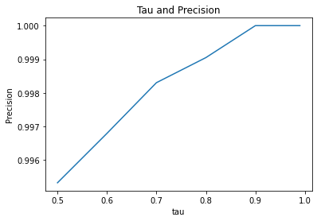

```python
plt.title('Tau and Precision')
plt.xlabel('tau')
plt.ylabel('Precision')
plt.plot(x_tau,y_prec)
plt.show()
```

#### Deliverable 3.6

Describe what you observe with thresholding (e.g., what happens to precision as the threshold increases?), and explain why you think this happens.

**As the threshold increases you can also see that the precision increases. This is because as tau increases so does the chance of correctly classification.**

## Problem 4: Sparse learning [5604: 5 points; 4604: +3 EC points]

Add the `penalty` argument to `SGDClassifier` and set the value to `'l1'`, which tells the algorithm to use L1 regularization instead of the default L2. Recall from lecture that L1 regularization encourages weights to stay at exactly $0$, resulting in a more "sparse" model than L2. You should see this effect if you examine the values of `classifier.coef_`.

#### Deliverable 4.1: Write a function to calculate the number of features whose weights are nonzero when using L1 regularization. Calculate the number of nonzero feature weights when `alpha` is one of $[0.00001, 0.0001, 0.001, 0.01, 0.1]$. Create a plot where the x-axis is `alpha` and the y-axis is the number of nonzero weights, using a log scale for the x-axis.

[your solution should be plotted below]

```python
# your code here

def countFeatures():
    count = 0
    temp = 0
    test_alpha_so_far2 = []
    score_so_far2 = []
    test_score_so_far2 = []
    nonZero = []
    alpha_so_far2 = []
    for alpha2 in [0.00001,0.0001,0.001,0.01,0.1]:
        classifier = SGDClassifier(loss='log', max_iter=1000,
                                tol=1.0e-12, random_state=123,
                                penalty = 'l1',alpha = alpha2,eta0=100, average=False)
        test_classifier = SGDClassifier(loss='log', max_iter=1000, alpha=alpha2,
                               tol=1.0e-12, random_state=123, eta0=100, average=False)

        test_classifier.fit(X_test, Y_test)
        classifier.fit(X_train, Y_train)

        alpha_so_far2.append(alpha2)

#         test_accuracy = test_classifier.score(X_test,Y_test)
        accuracy = classifier.score(X_train,Y_train)
#         test_alpha_so_far.append(alpha2)
#         score_so_far.append(accuracy)
#         test_score_so_far.append(test_accuracy)

#         print("Training accuracy: %0.6f" % accuracy_score(Y_train, classifier.predict(X_train)))
#         print("Testing accuracy: %0.6f" % accuracy_score(Y_test, classifier.predict(X_test)))
#         print("Test:",classifier.predict_proba(X_test))
#         print("Train:",classifier.predict_proba(X_train))
#         print(classifier.coef_)
        for i in classifier.coef_:
            for j in i:
#                 print(j)
                if j != 0:
#                     print(i[count])
#                     print("\n")
                    temp = j
                    nonZero.append(temp)
                else:
                    pass

#     print(nonZero)
#     print(alpha_so_far2,nonZero)
    plt.title('Non-Zero weights')
    plt.xlabel('alpha')
    plt.ylabel('Non-Zero weights')
    plt.semilogx(alpha, np.sin(2*np.pi*alpha))

    plt.plot(alpha_so_far2, nonZero)
#     plt.plot(test_alpha_so_far, test_score_so_far,'g-',label='Testing Accuracy')

    plt.legend()
    plt.show()
```

[output not shown]

[figure not shown]

```python
countFeatures()
```

# Comments

This assignment was very challenging for but despite not meeting the requirements for some of the deliveribles, I felt like I was very close with some minor misunderstandings.

1) for Deliverables 3.2.1 and 3.3 I felt like I was very close but I was tripped up by the "Maximum number of iteration reached before ". I wasn't sure how to fix it to stop once it converges.

2) With the last Deliverable, I felt like I was very close to getting a plot which showed alpha on the x and the non-zero weights, but I had trouble graphing lists of two different sizes. Was I supposed to graph these non-zero weights at each instance of alpha?

I would really like to understand this stuff so please let me know if you can see what I did wrong and can see I am missing something in particular.

```python
import matplotlib.pyplot as plt
plt.title('Testing vs Training Accuracy')
plt.xlabel('alpha')
plt.ylabel('accuracy')
plt.semilogx(alpha, np.sin(2*np.pi*alpha))

plt.plot(alpha_so_far, score_so_far,'r-',label='Training Accuracy')
plt.plot(test_alpha_so_far, test_score_so_far,'g-',label='Testing Accuracy')

plt.legend()
plt.show()
```

[output not shown]